# Tidy Tuesday Week 6

National Highways Traffic Flow

Savannah Damiano

2024-12-01

## Homework Instructions

- Have a dedicated Tidy Tuesday Folder
- Have proper script and file structure
- Submit a knitted RMarkdown file
- Save your visual in the output folder
- You must force yourself to learn at least one *NEW* thing each week (data wrangling, new geom, new table, new way to edit your theme, new package, rmarkdown, etc.)
- You do not have to use the entire weekly dataset

## Load Libraries

```r
library(here)            #to simplify file paths
library(tidyverse)       #data manipulation, visualization and analysis
library(tidytuesdayR)    #for weekly datasets
library(leaflet)         #interactive maps
library(htmlwidgets)     #to upload my leaflet graph to output
library(ggmap)
library(maps)
```

## Load Data

```r
tuesdata <- tidytuesdayR::tt_load(2024, week = 49)

A64_traffic <- tuesdata$A64_traffic

head(A64_traffic)
```

```
## # A tibble: 6 × 29
##   SiteId `Site Name` `Report Date`       `Time Period Ending` `Time Interval`
##    <dbl>       <dbl> <dttm>              <time>                         <dbl>
## 1   6867    30361338 2021-05-01 00:00:00 00:14                              0
## 2   6867    30361338 2021-05-01 00:00:00 00:29                              1
## 3   6867    30361338 2021-05-01 00:00:00 00:44                              2
## 4   6867    30361338 2021-05-01 00:00:00 00:59                              3
## 5   6867    30361338 2021-05-01 00:00:00 01:14                              4
## 6   6867    30361338 2021-05-01 00:00:00 01:29                              5
## # ℹ 24 more variables: `0 - 520 cm` <dbl>, `521 - 660 cm` <dbl>,
## #   `661 - 1160 cm` <dbl>, `1160+ cm` <dbl>, `0 - 10 mph` <dbl>,
## #   `11 - 15 mph` <dbl>, `16 - 20 mph` <dbl>, `21 - 25 mph` <dbl>,
## #   `26 - 30 mph` <dbl>, `31 - 35 mph` <dbl>, `36 - 40 mph` <dbl>,
## #   `41 - 45 mph` <dbl>, `46 - 50 mph` <dbl>, `51 - 55 mph` <dbl>,
## #   `56 - 60 mph` <dbl>, `61 - 70 mph` <dbl>, `71 - 80 mph` <dbl>,
## #   `80+ mph` <dbl>, `Avg mph` <dbl>, `Total Volume` <dbl>, Name <chr>, …
```

## Plot 1

Attention! This is not the final map! I wanted a graph to represent where the data was collected because I had no idea :) .

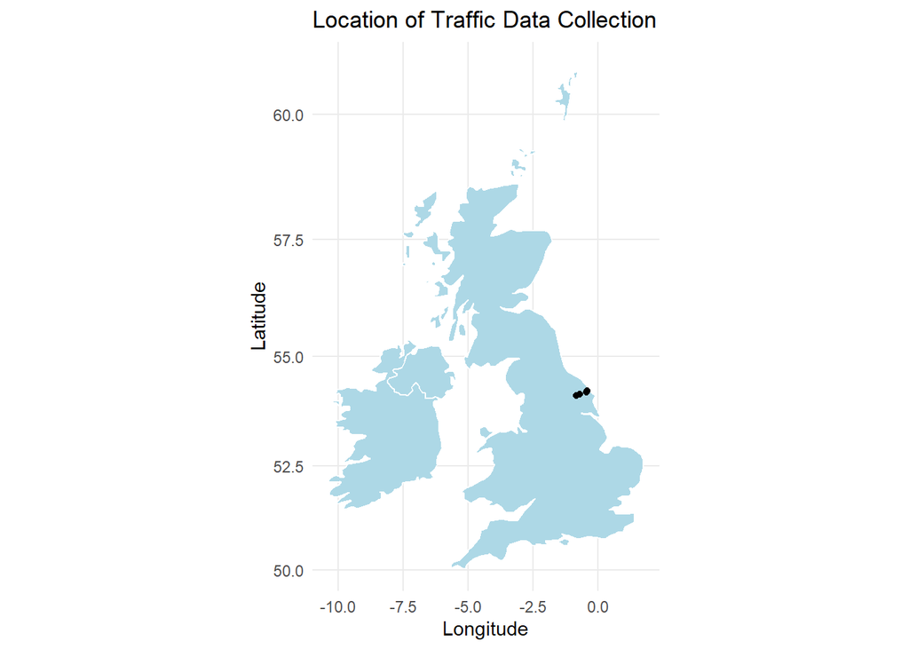

```r
# Get UK map data
uk_map <- map_data("world")

# Filter for the UK region (make sure it's correctly spelled)
uk_map <- uk_map %>% filter(region %in% c("UK", "United Kingdom", "Ireland", "Great Britain"))

# Plot the UK map with traffic data
p1 <- ggplot() +
  geom_polygon(data = uk_map, aes(x = long, y = lat, group = group),
               fill = "lightblue", color = "white") +
  geom_point(data = A64_traffic,
             aes(x = Longitude,
                 y = Latitude)) +
  labs(title = "Location of Traffic Data Collection",
       x = "Longitude",
       y = "Latitude",
       size = "Traffic Volume",
       color = "Traffic Volume") +
  theme_minimal() +
  coord_map(projection = "mercator")

p1
```

## Plot 2

Also, I wanted to make an interactive map that shows the traffic level across four sites in the UK.

```r
#Create thresholds for traffic

low_threshold <- quantile(A64_traffic$`Total Volume`, 0.25, na.rm = TRUE)  # 25th percentile to use as low traffic
high_threshold <- quantile(A64_traffic$`Total Volume`, 0.75, na.rm = TRUE) # 75th percentile to use as high traffic
# use '' around words because there is a space that separated them in original data frame

#Create a leaflet map

p2 <- leaflet(A64_traffic) %>%

# Default OpenStreetMap tiles
  addTiles() %>%

# Satellite imagery from Esri
  addProviderTiles("Esri.WorldImagery") %>%

# Set the initial view of the map. Centered on Yorkshire UK
  setView(lng = -0.6946696, lat = 54.1581, zoom = 10) %>%

# Add circle markers to represent traffic data at specific locations
  addCircleMarkers(
    lng = ~Longitude,     #long coords for circle placement
    lat = ~Latitude,      #lat coords for circle placement
    radius = ~sqrt(`Total Volume` / 10),  # scales circle size by traffic volume
    color = ~case_when(   #change colors depending on traffic volume
      `Total Volume` <= low_threshold ~ "green",   #low traffic- green
      `Total Volume` > low_threshold & `Total Volume` <= high_threshold ~ "orange", #moderate traffic - orange
      `Total Volume` > high_threshold ~ "red"), #high traffic - red
    popup = ~paste("Site Name:", `Site Name`, "<br>",         # apparently you have to add "<br>" as a line break for popup
                   "Total Volume:", `Total Volume`, "<br>",
                   "Avg Speed (mph):", `Avg mph`))%>%         # Add a popup for each marker with traffic details

 addLegend(
    position = "bottomright",  # Position of the legend on the map
    colors = c("green", "orange", "red"),  # Color map for traffic levels
    labels = c(
      paste("Low Traffic"),          #labels
      paste("Moderate Traffic"),
      paste("High Traffic")
    ),
    title = "Traffic Volume") %>%    #legend title

addControl(
    html = "<h3>Traffic Level</h3>", #add the <h3> and </h3> to indicate the beginning and end of HTML
    position = "topleft"
  ) %>%                              #add a title in the map

  addMiniMap(width = 150, height = 150)    #add a mini map to show were we are in the UK

p2
```

[interactive chart not shown]

```r
#save to output folder

saveWidget(p2, file = "HomeworkMap2.html")
```

## Hey Savannah, what did you learn?

Aw thanks for asking <3

- I learned about the [quantile()](https://www.statology.org/quantile-function-in-r/) function. This function can help to divide rank within a data set. I used this function to be able to create different traffic volume thresholds for my leaflet map.
- I learned a lot in in [leaflet](https://rstudio.github.io/leaflet/articles/legends.html).
  - How to add a legend.
  - How to create circle markers that have different color levels for different values.
  - How to create circle markers for specific locations on a map.
  - How to change the type of map using [addProviderTiles()](https://rstudio.github.io/leaflet/reference/addProviderTiles.html).
  - How to add a title to a leaflet align.
  - How to make a [minimap](https://r-charts.com/spatial/interactive-maps-leaflet/).